# Unit 12 - Difference in Differences

Jim Flynn

October 19, 2026

## Before we dive in, storytime

- Does anyone know who John Snow is?
  - Not this guy

[figure not shown]

## The first natural experiment?

- When RCTs are impossible, we want to find a setting where some treatment occurs for some groups and not others
  - Whether someone received treatment should be *as good as* random
  - What does that mean?

## Enter John Snow and the Cholera epidemic

- John Snow was a physician in London in the 1800s
- At that time, tens of thousands of people died of this new ‘plague’
- Common belief was that it traveled through the air in *miasmas*

## Squaring miasma theory with data

- Unfortunately, none of the treatments for airborn illnesses were working
  - Quarantining the sick
  - Even covered people with burlap bags
  - No effect on spread

## More issues with miasma theory

- Cholera tended to follow human commerce
  - Sailors only got sick if they docked
- Hit poor communities the hardest
  - These were more dense/had worse hygiene
- Would often hit only one apartment building
  - Snow noticed these often had different water sources…

## A new theory

- Snow wondered if maybe cholera was caused by a living organism
  - Entered the body through food or drink
  - Multiplied in the stomach, causing people to get sick
  - Evacuations put more organisms into water supply
  - On and on we go -This would explain why it seemed to hit London in waves

## This makes more sense, but how to prove it?

- Snow needed a natural experiment!
- Needs a setting where some people get contaminated water and some get clean water
  - This should be essentially random
  - Not related to poverty or hygiene
- Enter the Lambeth Water Company!

## Water distribution in England

- In 1800s, several water companies served London
- They took water from the Thames
  - distributed it throughout the city
- Often next door neighbors got different water
- In 1849, the Lambeth Water Company moved their intake cite upstream from London
  - They were getting water before it became contaminated by sewage!

## Opportunity to test hypothesis

- This gave Snow a chance to test his hypothesis
- If Lambeth customers had fewer cases of cholera after 1849, that would be compelling evidence that contaminated water *causes* cholera
- But we said that cholera came in waves, what if 1849 was just the peak of the wave?
  - How to separate the effect of clean water from the effect of time?

## Snow needed a counterfactual!

- He chose the Southwark and Vauxhall Waterworks Company
- Similar to Lambeth, but did not move intake
- Snow wrote a book on the similarities between the two
  - They often cut irregular paths through neighborhoods
  - Houses across the street often had one or the other
  - Similar poverty rates among customers

## Shoe leather approach

- Snow meticulously collected data on household water supplier throughout London
  - Went door to door and asked families
  - If they didn’t know, he would use a saline test
- He linked this to mortality records from London
  - He used **merge(df_water,df_cholera,by=“address”)** in R

## Results

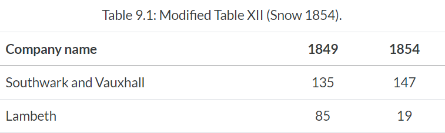

```r
diff_lambeth <- 19 - 85
diff_sv <- 147 - 135
diff_in_diffs <- diff_lambeth - diff_sv
diff_in_diffs
```

```
## [1] -78
```

## Famous Broad Street Map

[figure not shown]

## And thus DiD was born

- This study is a great example of how we can use observational data to test a hypothesis
- It combines shoe leather with strong statistical analysis
  - It has saved thousands of lives

## The DiD Idea

- We have a treated group that we observe *both before and after they’re treated*
- And we have an untreated group over the same period
- The treated and control groups probably aren’t identical
  - We *control for group similarities* with fixed effects
  - Differences between T and C which are constant over time are no problem
- Why do we need a control group? Can’t we just see if T responds to treatment?

## Illustrating the problem

- You work for Purell in their marketing team
- You put together a great new ad campaign…
  - In February 2020
- After your campaign, sales *skyrocketed*
- You ask to be made CEO

## The Difference-in-differences Solution

- We can add a *control group* that did *not* get the treatment
- Then, any changes that are the result of *time* should show up for that control group, and we can get rid of them!
- The change for the treated group from before to after is because of both treatment and time.
- If we measure the time effect using our control, and subtract that out, we’re left with just the effect of treatment!

## Back to John Snow

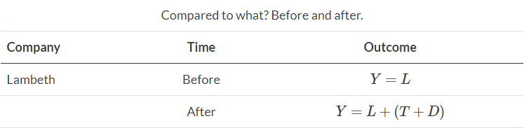

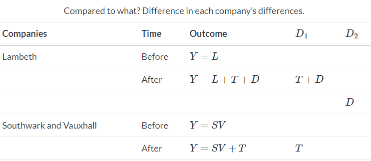

## In a regression framework

$$Y = \underbrace{\beta_0}_{\text{SV Pre}}
+ \underbrace{\beta_1 Post}_{\text{Ctrl for time}} +
\underbrace{\beta_2 Treat}_{\text{Ctrl for group}} + \underbrace{\beta_3
Post*Treat}_{\text{Treatment Effect}}$$
$\beta_0 = 135$

$\beta_1 = 12$

$\beta_2 = -50$

$\beta_3 = -78$

## Let’s check that this works

```r
snow_df <- data.frame(matrix(ncol=2,nrow=4))
colnames(snow_df) <- c("year","deaths")
snow_df[1:2,1] <- 1849
snow_df[3:4,1] <- 1855
snow_df[1,2] <- 135
snow_df[2,2] <- 85
snow_df[3,2] <- 147
snow_df[4,2] <- 19
snow_df$company <- c("SV","Lambeth","SV","Lambeth")
snow_df
```

```
##   year deaths company
## 1 1849    135      SV
## 2 1849     85 Lambeth
## 3 1855    147      SV
## 4 1855     19 Lambeth
```

## Running the regression

```r
snow_df <- snow_df %>%
  mutate(treat = company == "Lambeth",
         post = year == 1855,
         treat_post = treat*post)
snow_lm <- lm(deaths ~ post + treat + treat_post, data = snow_df)
summary(snow_lm)$coefficients[,1]
```

```
## (Intercept)    postTRUE   treatTRUE  treat_post
##         135          12         -50         -78
```

Looks like it worked!

## Generalizing DiD to TWFE

Consider the following regression specification:

$$Y = \underbrace{\gamma_g}_{\text{Group
FE}} + \underbrace{\delta_t}_{\text{Time FE}} + \underbrace{\beta_3
Post*Treat}_{\text{Treatment Effect}}$$

## Class exercise

- Use did_toy.R
- Calculate the DiD treatment effect manually
- Then do so using the basic DiD
- Then do so using TWFE
- Confirm that they are all the same

## Loading did_toy.rds

```r
did_toy <- readRDS("did_toy.rds")
```

## Solution - Manual Calculation

```r
did_manual <- did_toy %>%
  group_by(post,treat) %>%
  summarise(mean_y = mean(Y))
did_manual
```

```
## # A tibble: 4 × 3
## # Groups:   post [2]
##   post  treat mean_y
##   <lgl> <lgl>  <dbl>
## 1 FALSE FALSE   9.97
## 2 FALSE TRUE    9.09
## 3 TRUE  FALSE  11.5
## 4 TRUE  TRUE   12.5
```

## Now calculate the DID

```r
t_pre <- did_manual$mean_y[did_manual$post==FALSE&did_manual$treat==TRUE]
t_post <- did_manual$mean_y[did_manual$post==TRUE&did_manual$treat==TRUE]
c_pre <- did_manual$mean_y[did_manual$post==FALSE&did_manual$treat==FALSE]
c_post <- did_manual$mean_y[did_manual$post==TRUE&did_manual$treat==FALSE]

t_dif <- t_post - t_pre
c_dif <- c_post - c_pre

did <- t_dif - c_dif
did
```

```
## [1] 1.932862
```

## Now with a basic did regression

```r
did_lm <- lm(Y ~ post + treat + treat_post,    data = did_toy)
summary(did_lm)$coefficients
```

```
##                  Estimate Std. Error   t value      Pr(>|t|)
## (Intercept)     9.9672288 0.03957033 251.88645  0.000000e+00
## postTRUE        1.5029836 0.05660614  26.55160 3.657467e-150
## treatTRUE      -0.8777987 0.05632579 -15.58431  4.022135e-54
## treat_postTRUE  1.9328617 0.07992487  24.18348 1.287527e-125
```

## Now with TWFE

```r
twfe_lm <- plm(Y ~ treat_post,
    data = did_toy, index = c('group', 'year'), model = 'within',
    effect = 'twoways')
summary(twfe_lm)$coefficients
```

```
##                Estimate Std. Error t-value      Pr(>|t|)
## treat_postTRUE  1.93363 0.07991098 24.1973 9.398278e-126
```

## DiD Assumption

- Must be true that $Post$ captured the effect of time
- The difference for SV from pre to post has to be what **would have happened** for Lambeth if they had not moved their water upstream
- In other words, we need to believe they were on **parallel trends**
- More generally, we can call this the **equal counterfactual trends** assumption
  - Everything in DiD hinges on this.

## What happens if parallel trends doesn’t hold?

- The cholera case is a simple 2x2 comparison
  - Treatment group (k)
  - Untreated group (u)

$$\underbrace{\hat{\delta}_{ku}^{2x2}}_{\text{DiD}}
= \underbrace{(\bar{y}_k^{post} - \bar{y}_k^{pre})}_{\text{Treated
Diff}} - \underbrace{(\bar{y}_u^{post} -
\bar{y}_u^{pre})}_{\text{Control Diff}}$$

Which we can rewrite using potential outcomes notation

$$\equiv (E[Y_k^1|Post]-E[Y_k^0|Pre]) -
(E[Y_u^0|Post]-E[Y_u^0|Pre])$$

## We can manipulate this using our switching equation

$$(E[Y_k^1|Post]-E[Y_k^0|Pre]) -
(E[Y_u^0|Post]-E[Y_u^0|Pre])$$

We can add $0 = E[Y_k^0|Post] - E[Y_k^0|Post]$

to get:

$$\hat{\delta}_{ku}^{2x2} =
\underbrace{E[Y_k^1|Post] - E[Y_k^0|Post]}_{\text{ATT}}$$

$$+\underbrace{[E[Y_k^0|Post] -
E[Y_k^0|Pre]] - [E[Y_u^0|Post] - E[Y_u^0|Pre]]}_{\text{Difference in
untreated trends}}$$

- Treatment effect only identified if last term is 0
- This is **untestable** since we never observe $E[Y_k^0|Post]$

## Sidenote - consider Bertrand et al (2004)

- Notice that this 2x2 case is what they referred to as the ideal
  - Removes serial correlation and gives accurate SEs
- Downside of this - it makes PT assumption difficult to assess
- Is there anything we can do to fix this?

## For example

- In the 2x2 case, will this show up as a treatment effect?

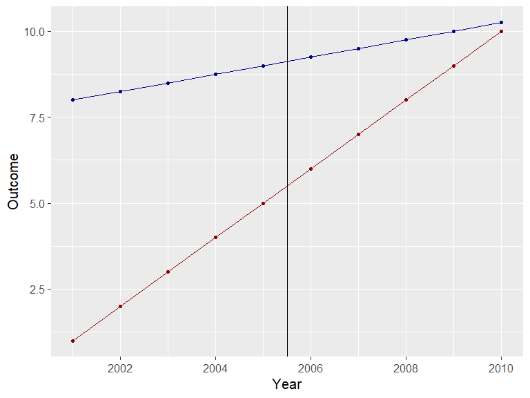

## Looking at the 2x2

```r
pre_t <- mean(1:5)
post_t <- mean(6:10)
pre_c <- mean(seq(8,9,.25))
post_c <- mean(seq(9.25,10.25,.25))

t_dif <- post_t - pre_t
c_dif <- post_c - pre_c

DiD <- t_dif - c_dif
DiD
```

```
## [1] 3.75
```

## Enter the Event-Study

- We can never **prove** the PT assumption
- If T and C were **trending** similarly pre-treatment, it is easier to believe they would have continued.
- If T happens all at once, then you can simply plot the data

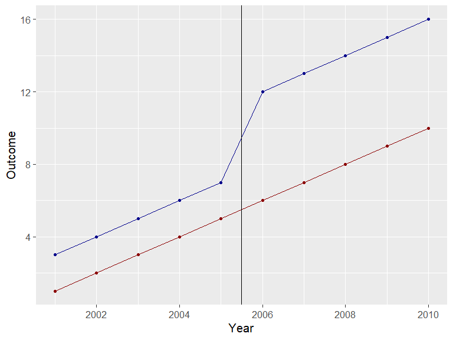

## This doesn’t work if treatment is staggered

- How awful does this look?

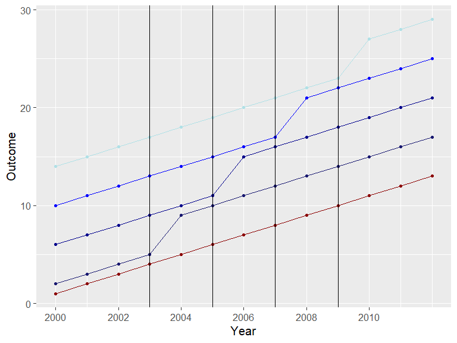

## Event Study Plot

- The idea of an event study is seeing if we can collapse the last graph into one that looks like the one before
- Need to convert time to ‘event time’
- Instead of ‘year’, it’s ‘years until treatment’
  - We do this using **leads** and **lags**
- We will now estimate a regression model that takes the difference between T and C for each year leading up to and after treatment.

## We run the following regression:

$$Y_{gt} = \gamma_g + \lambda_t +
\sum_{\rho=-q}^{-1}\theta_{\rho} D_{gt} + \sum_{\rho=1}^{3}\delta_{\rho}
D_{gt} + X_{gt} + \epsilon_{gt}$$

- $\gamma_g$ are group FEs
- $\lambda_t$ are year FEs
- $\theta$’s are the leads
- $\delta$’s are the lags
- $X_{gt}$ are other controls

## Simple event-study has issues

- We will talk about during Goodman-Bacon (2021)
- For now, I’ll show you how to code the event-study from the simple example below

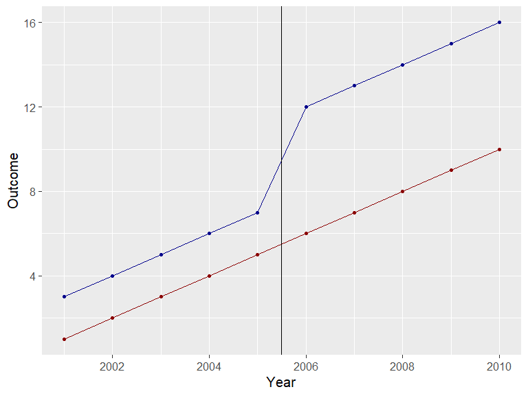

## Coding up the event-study manually

- We can create the leads and lags

```r
df_es <- melt(df,id='year')%>%
  mutate(treat = variable == "t2",
         lead4 = year == 2001 & treat == TRUE,
         lead3 = year == 2002 & treat == TRUE,
         lead2 = year == 2003 & treat == TRUE,
         lead1 = year == 2004 & treat == TRUE,
         lag1 = year == 2006 & treat == TRUE,
         lag2 = year == 2007 & treat == TRUE,
         lag3 = year == 2008 & treat == TRUE,
         lag4 = year == 2009 & treat == TRUE,
         lag5 = year == 2010 & treat == TRUE,
         )
```

## And here is the regression

- We don’t have enough observations here to generate SE’s, but the coefficients look right

```
##               Estimate Std. Error t-value Pr(>|t|)
## lead4TRUE 1.218643e-15        Inf       0      NaN
## lead3TRUE 5.346003e-15        Inf       0      NaN
## lead2TRUE 3.453907e-15        Inf       0      NaN
## lead1TRUE 6.783575e-16        Inf       0      NaN
## lag1TRUE  4.000000e+00        Inf       0      NaN
## lag2TRUE  4.000000e+00        Inf       0      NaN
## lag3TRUE  4.000000e+00        Inf       0      NaN
## lag4TRUE  4.000000e+00        Inf       0      NaN
## lag5TRUE  4.000000e+00        Inf       0      NaN
```

## Class exercise

- Use the did_toy dataset and now run the event-study version.

## Solution

```r
did_toy <- did_toy %>%
  mutate(lead1 = year == 2020 & treat == TRUE,
         lag1 = year == 2022 & treat == TRUE,
         lag2 = year == 2023 & treat == TRUE,)

did_lm <- plm(Y ~ lead1 + lag1 + lag2,
    data = did_toy, index = c('treat', 'year'), model = 'within',
    effect = 'twoways')
summary(did_lm)$coefficients
```

```
##             Estimate Std. Error    t-value     Pr(>|t|)
## lead1TRUE 0.06098977  0.1126182  0.5415624 5.881321e-01
## lag1TRUE  2.00747219  0.1132282 17.7294322 2.842630e-69
## lag2TRUE  1.92139243  0.1128541 17.0254489 4.243082e-64
```

## Setting this up to plot

```r
es_plot <- summary(did_lm)$coefficients

es_df <- tibble(
  sd = es_plot[1:3,2],
  mean = es_plot[1:3,1],
  year = c(2020,2022,2023))

#Add a zero for 2021
es_df[4,1:2] <- 0
es_df[4,3] <- 2021

es_df <- es_df %>% arrange(year) %>%
  mutate(lb = mean - (1.96 * sd),
         ub = mean + (1.96 * sd))
```

## And plotting:

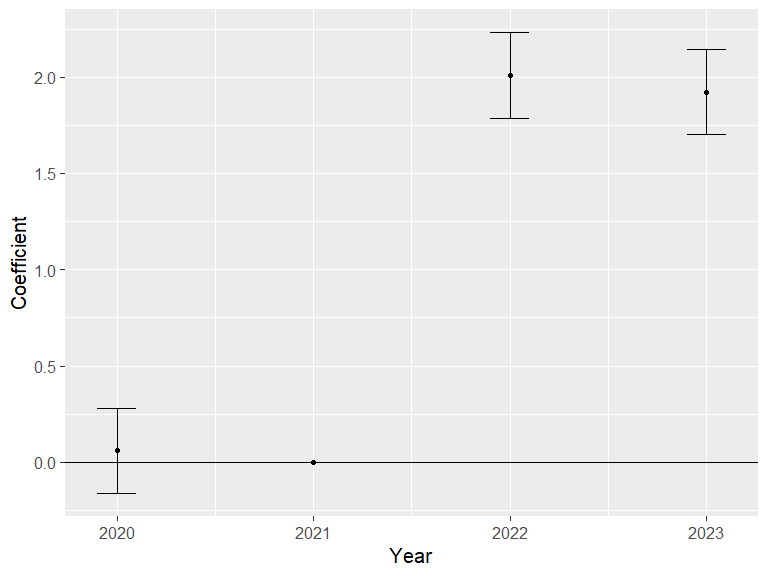

```r
  ggplot(aes(x = year, y = mean), data = es_df) +
  geom_point()+
  geom_hline(yintercept = 0) + ylab("Coefficient") + xlab("Year") +
  geom_errorbar(aes(ymin = lb, ymax = ub), width = 0.2,
                position = position_dodge(0.05))
```

## Here are some examples

Callison et al (2023)

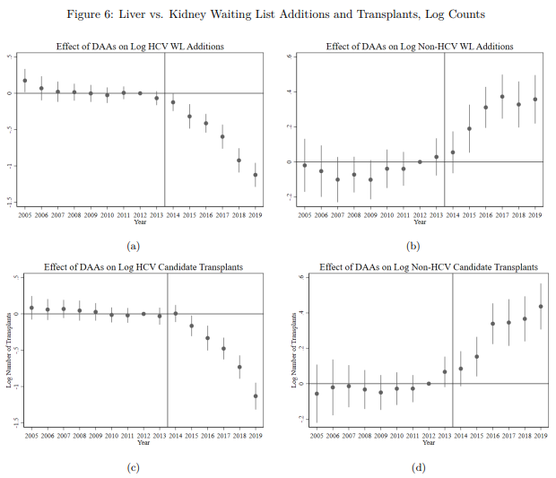

## Referring surgeons reactions to a mistake

Sarsons (2017)

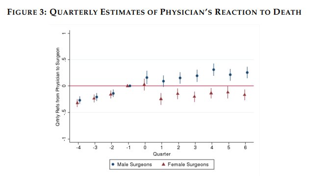

## Provide evidence for PT assumption

- Just because they moved similarly before the event does not mean they **would have** continued to do so
- Still, the visual evidence is hard to ignore

## Notice that event-studies address a lot of Bertrand (2004) issues

- Trends will not get picked up as treatment effect
- We are giving each year it’s own standard error
  - Serial correlation across time not a problem
- Still need to think about clustering
- Coefficients of interest are measured as differences from a reference point

## Randomization Inference

- Let’s say you found some big effect
- Clearly things change a lot right after treatment
- You are concerned, however, that your standard errors are wrong
- Can we estimate an effect without using standard errors at all?

## Indulge me for a minute

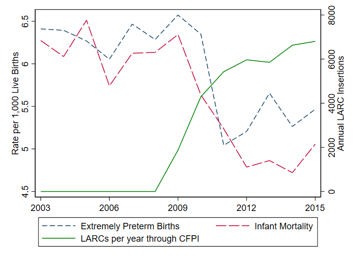

## Clearly looks like a treatment effect

- This was 38 counties in Colorado
- But maybe infant health outcomes vary a lot?
- What if these changes just aren’t that big?
- Maybe things just got a little better at random

## Let’s pretend it was 38 other counties

- What if I randomly pick 38 counties from the US
- Look at their IMR and EPB rate from 2006-09 and 2011-14
- Calculate the difference in raw and pct terms
- Do this one million times
- See how many have bigger declines than Colorado
- $\text{P-value} = \frac{\text{# bigger decline}}{1,000,000}$

## Outcome

- In each case, the Colorado decline is bigger than over 99% of the placebos

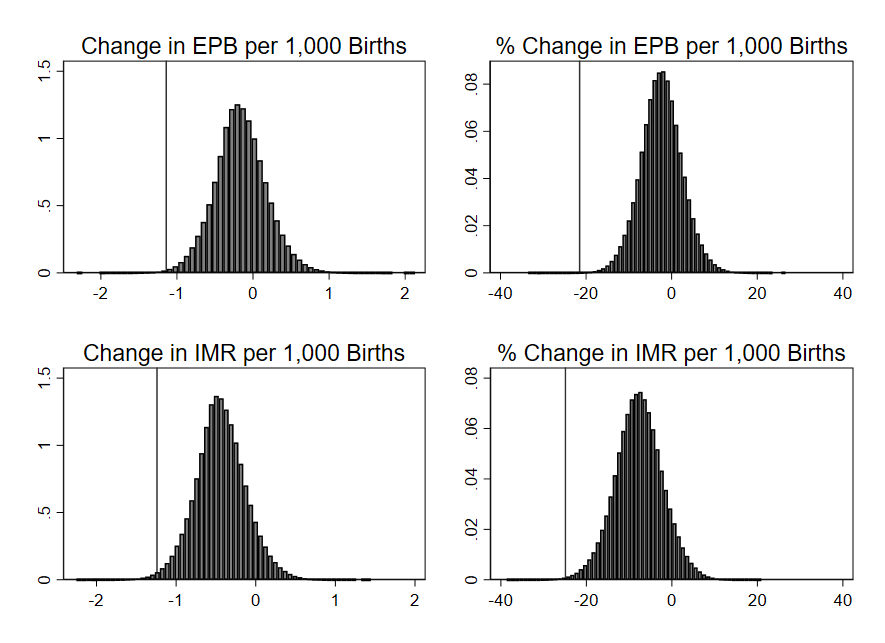

## Triple-Diff (DDD)

- Let’s say we are analyzing the employment effects of the minimum wage
- We look at fast food restaurants in NJ and PA
- Gather data before and after NJ raises the minimum wage
- DiD estimate should tell us the ATT
  - Card and Krueger (1994) did exactly this

## But states are pretty different

- Even bordering ones
  - Maybe especially PA and NJ
- What if there was a state-level change in trend?
- This would get picked up as in the DiD estimate

## Solution - include another industry

- We could include higher wage workers in both PA and NJ
  - Maybe construction?
- Want something similar enough to fast food that it would have the same common shock, but something where the minimum wage is non-binding

## Solution - how it works

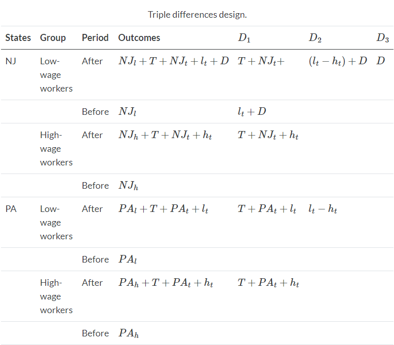

## What did this do?

- Adding the high wage workers gave us an additional difference to compare
- This ruled out any state-specific change in trend
  - As long as it affected high and low wage workers the same
- Difference:
  - 1 Before vs. After
  - 2 High vs. Low
  - 3 NJ (treated) vs. PA (control)

## How the heck do we set this regression up?

$$E_{sit} = \beta_1 After_t + \beta_2
Low_i + \beta_3 Treated_s + \beta_4 After_t*Low_i$$
$$+ \beta_5 After_t*Treated_s + \beta_6
Low_i*Treated_s +$$
$$\beta_7
After_t*Low_i*Treated_s$$

## Synthetic Control

- Sometimes there is not an obvious control group
- Assume you have an intervention at time $t$
- There are other states or counties which *could* work
  - We will call this our *donor pool*
- Including them all doesn’t seem right
- Any specific choices will be somewhat ad hoc

## Let the data choose for you!

- The Synthetic Control Method (SCM) will choose your group for you
  - Similar to how LASSO automates model selection
- How does this work?
  - You choose which variables are important for predicting outcome
- R will create a weighted average of the donor pool which best matches T and C
- Combination of comparison units can do a better job of mimicking $E[Y_0^k|Post]$

## Advantages of SCM

- Constructing counterfactual does not require access to treated outcomes
  - Helps avoid *peeking* at results
- Weights make it *explicit* what each unit in the donor pool is contributing
  - Can cause headaches (but shouldn’t)

## How does it work

- There are $J$ groups in the donor pool
- You choose $M$ predictor variables
- SCM chooses $weights = W = w_1,w_2,...,w_j$ where
  - $w_j \geq 0$ for all $j \in J$
  - $\sum_{j=1}^J w_j = 1$
  - Which minimize:

$\sum_{m=1}^k (X_{Tm} - \sum_{j=1}^J w_jX_{jm})^2$

## What just happened?

- This process chooses a control group which matches our treated group as closely as possible on all the variables we think predict the outcome
- Then we compare outcomes
- We measure the causal effect of the intervention in period $t$ as:

$Y_{Tt} - \sum_{j=1}^J w_j^* Y_{jt}$

- Where $w_j^*$ is our optimally chosen weight

## Let’s see an example

- Abadie et al (2010) use California’s prop 99 (cigarette tax) to look for the effect of the tax on cigarette purchases
- Here are raw trends in sales:

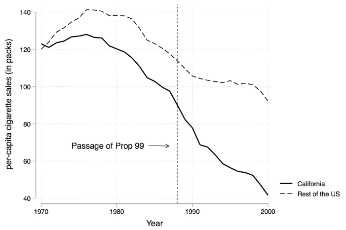

## Now compared to synthetic california

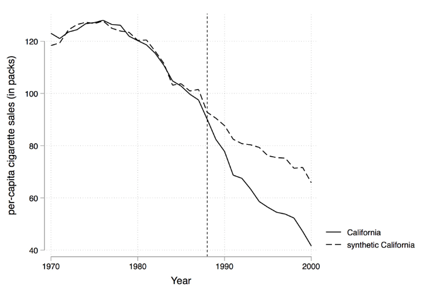

## What does synthetic California look like?

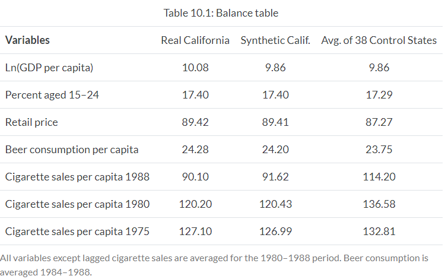

## California difference from Synthetic California

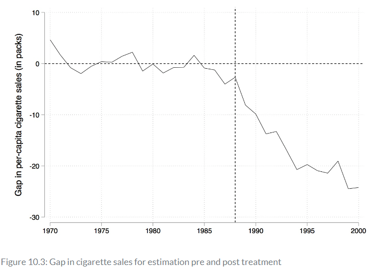

## But how do we calculate p-values?

- SCM produces just one comparison group
- How do we know if the difference is *large*
- Abadie et al (2010) recommend we follow a similar procedure to randomization inference

## Synth P-value calculation

- Iteratively apply SCM to each group in the donor pool
- Calculate RMSPE for each placebo for the pre-period:

$$RMSPE =
(\frac{1}{T_T-T_0}\sum_{t=T_0+t}^T(Y_{Tt}-\sum_{j=1}^Jw_j^*Y_{jt})^2)^{\frac{1}{2}}$$

- Calculate RMSPE for the post-period
- Calculate the ratio of post-to-pre RMSPE
- Sort this ratio in descending order
- $\text{p-value} = \frac{RANK}{TOTAL}$

## Synth comparison graph

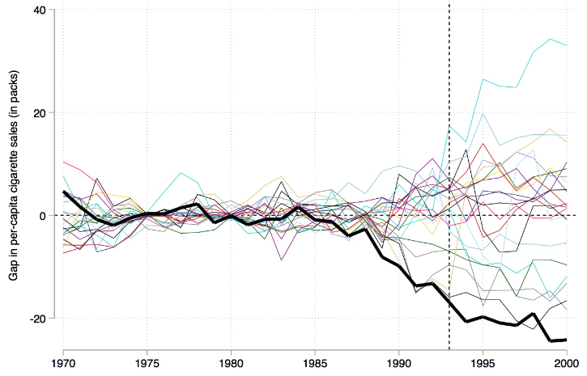

## RMSPE Distribution Graph

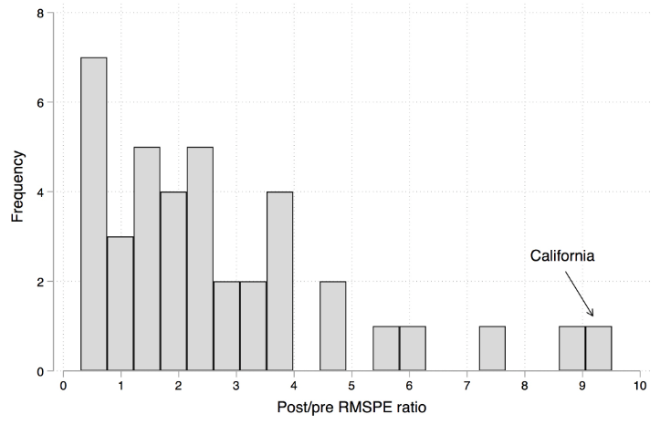

## How to code this?

- Loading data for Cunningham and Kang (2019)

```r
read_data <- function(df)
{
  full_path <- paste("https://github.com/scunning1975/mixtape/raw/master/",
                     df, sep = "")
  df <- read_dta(full_path)
  return(df)
}

texas <- read_data("texas.dta") %>%
  as.data.frame(.)
```

## Synth code

```r
dataprep_out <- dataprep(
  foo = texas,
  predictors = c("poverty", "income"),
  predictors.op = "mean",
  time.predictors.prior = 1985:1993,
  special.predictors = list(
    list("bmprison", c(1988, 1990:1992), "mean"),
    list("alcohol", 1990, "mean"),
    list("aidscapita", 1990:1991, "mean"),
    list("black", 1990:1992, "mean"),
    list("perc1519", 1990, "mean")),
  dependent = "bmprison",
  unit.variable = "statefip",
  unit.names.variable = "state",
  time.variable = "year",
  treatment.identifier = 48,
  controls.identifier = c(1,2,4:6,8:13,15:42,44:47,49:51,53:56),
  time.optimize.ssr = 1985:1993,
  time.plot = 1985:2000
)
```

## Running the SCM

```r
synth_out <- synth(data.prep.obj = dataprep_out)
```

```
##
## X1, X0, Z1, Z0 all come directly from dataprep object.
##
##
## ****************
##  searching for synthetic control unit
##
##
## ****************
## ****************
## ****************
##
## MSPE (LOSS V): 2015107
##
## solution.v:
##  0.07154915 0.02736536 0.8923763 5.5e-09 2.42e-08 0.008709159 7.6e-09
##
## solution.w:
##  3.1624e-06 2.409e-07 2.1267e-06 1.84496e-05 0.3414498 5.67e-07 2.118e-07 2.353e-07 5.36e-08 0.2981352 3.819e-07 2.736e-07 1.27466e-05 8.934e-07 1.9113e-06 1.6149e-06 8.583e-07 1.13756e-05 0.3599649 1.8153e-06 2.789e-07 3.058e-07 4.3669e-06 5.491e-07 7.4e-09 1.5586e-06 1.03716e-05 9.868e-07 4.019…
```

## Plot 1

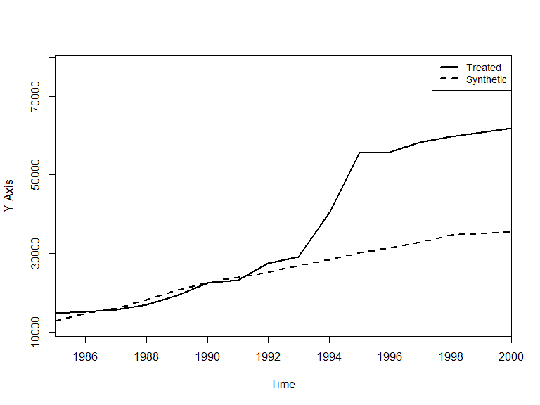

```r
path.plot(synth_out, dataprep_out)
```

## Plot 2

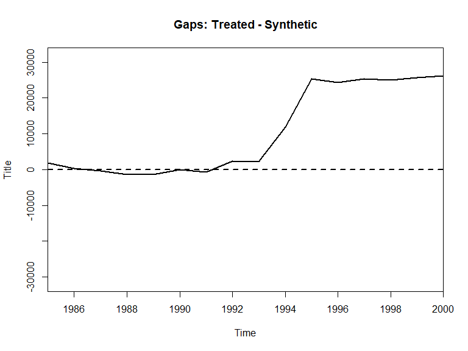

```r
gaps.plot(synth_out, dataprep_out)
```